# Análise de Agrupamentos

## Método k-médias (*k-means*)

### Esquematicamente

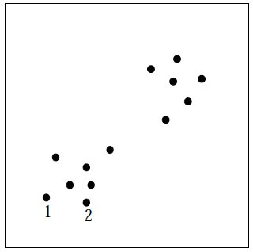

## Método k-médias (*k-means*)

### Esquematicamente

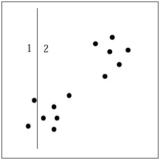

## Método k-médias (*k-means*)

### Esquematicamente

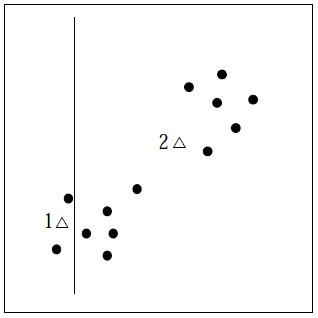

## Método k-médias (*k-means*)

### Esquematicamente

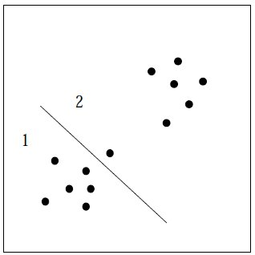

## Método k-médias (*k-means*)

### Esquematicamente

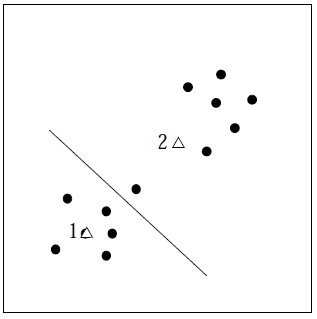

## Método k-médias (*k-means*)

### Esquematicamente

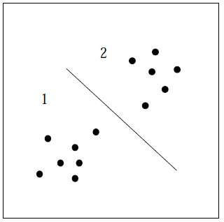

## Método k-médias (*k-means*)

### Esquematicamente

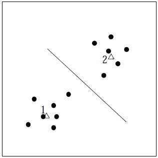

## Método k-médias (*k-means*)

### Esquematicamente

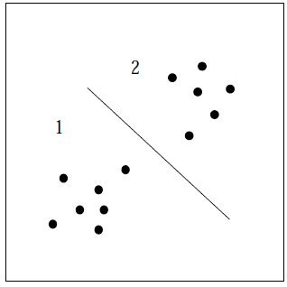

## Método k-médias (*k-means*)

### Esquematicamente

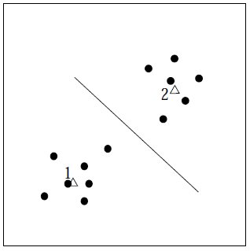

## Método k-médias (*k-means*)

### Esquematicamente

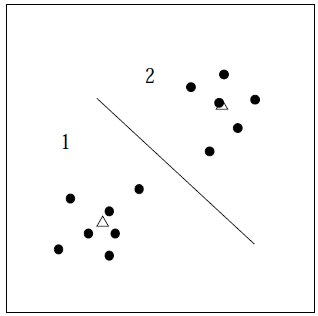

## Método k-médias: comentários finais

- O algoritmo é sensível à configuração inicial dos clusters (passo $a)$), podendo produzir resultados diferentes mediante diferentes partições iniciais.
- O usual é considerar, inicialmente, $k$ “sementes”, que seriam $k$ pontos definidos em $R^p$.
- O processo inicia alocando cada elemento à semente mais próxima, e atualizando o ponto de referência do cluster (centroide) cada vez que ele incorpora um novo elemento.
- Podemos definir as sementes como os vetores de observações de $k$ elementos selecionados aleatoriamente da base.

## Método k-médias: comentários finais

- **Nota:** Estabelecer alguma restrição quanto à distância das sementes, garantindo alguma distância mínima entre elas, pode ajudar na performance do método.
- As sementes podem ser definidas como $k$ vetores quaisquer definidos em $R^p$;
- Caso se considere algum mecanismo aleatório de seleção de sementes, é recomendável que o processo seja repetido um número $m$ de vezes, identificando-se, dentre as $m$ soluções obtidas, a solução ótima;

## Método k-médias: comentários finais

- Uma alternativa é rodar, inicialmente, uma análise hierárquica, e definir $k$ clusters;
- Os centroides dos $k$ clusters obtidos podem servir de semente para o algoritmo *k - means*.